# Value-at-Risk

**Kannan Singaravelu**

March, 2022

# Value-at-Risk

Value at Risk - **VaR** - is one of the most important metrics that is used to measures the risk associated with a financial position or a portfolio of financial instruments. VaR can be defined as the maximum loss with a confidence level over a predetermined period. Let's say that the 1-day 95% VaR of a portfolio is $\$100$. This means that 95% of the time, it is expected that - under normal market conditions - we will not lose more than $100 by holding our portfolio over one day.

Three approaches that are commonly used in the industry are

- **Parametric**
- **Historical**
- **Monte Carlo**

## Import Libraries

```python
# Data manipulation
import pandas as pd
import numpy as np
from numpy.linalg import multi_dot

from scipy.stats import norm
from tabulate import tabulate

# Import matplotlib for visualization
import matplotlib
import matplotlib.pyplot as plt

# Plot settings
plt.style.use('dark_background')
matplotlib.rcParams['figure.figsize'] = [24.0, 8.0]
matplotlib.rcParams['font.size'] = 10
matplotlib.rcParams['lines.linewidth'] = 2.0
matplotlib.rcParams['grid.color'] = 'black'

from helper import plot_var
```

## Retrieve Data

```python
# Load locally stored data
df = pd.read_csv('data/nasdaqstocks.csv', index_col=0, parse_dates=True)

# Check values
df
```

| Date | AMD | CSCO | INTC | INTU | NVDA |
| --- | --- | --- | --- | --- | --- |
| 2017-01-03 | 11.430000 | 25.985624 | 31.973001 | 110.028511 | 25.170732 |
| 2017-01-04 | 11.430000 | 25.831154 | 31.807016 | 110.249069 | 25.757994 |
| 2017-01-05 | 11.240000 | 25.891228 | 31.754612 | 110.929855 | 25.104115 |
| 2017-01-06 | 11.320000 | 25.942711 | 31.868174 | 112.381958 | 25.439690 |
| 2017-01-09 | 11.490000 | 25.899803 | 31.981743 | 112.045403 | 26.471098 |
| ... | ... | ... | ... | ... | ... |
| 2021-12-23 | 146.139999 | 61.915154 | 50.922092 | 634.972839 | 296.399994 |
| 2021-12-27 | 154.360001 | 63.048477 | 51.547329 | 652.013062 | 309.450012 |
| 2021-12-28 | 153.149994 | 63.157833 | 51.368690 | 649.026550 | 303.220001 |
| 2021-12-29 | 148.259995 | 63.585312 | 51.438164 | 647.278564 | 300.010010 |
| 2021-12-30 | 145.149994 | 63.247307 | 51.348843 | 642.613953 | 295.859985 |

1258 rows × 5 columns

## Calculate Returns

```python
# Calculate daily returns
returns = df.pct_change().dropna()
returns.head()
```

| Date | AMD | CSCO | INTC | INTU | NVDA |
| --- | --- | --- | --- | --- | --- |
| 2017-01-04 | 0.000000 | -0.005944 | -0.005191 | 0.002005 | 0.023331 |
| 2017-01-05 | -0.016623 | 0.002326 | -0.001648 | 0.006175 | -0.025385 |
| 2017-01-06 | 0.007117 | 0.001988 | 0.003576 | 0.013090 | 0.013367 |
| 2017-01-09 | 0.015018 | -0.001654 | 0.003564 | -0.002995 | 0.040543 |
| 2017-01-10 | -0.004352 | 0.006627 | -0.001912 | -0.003433 | -0.007550 |

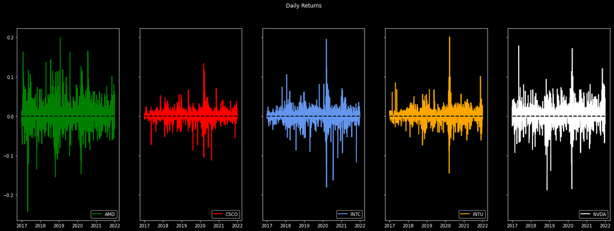

```python
# Visualize daily returns
fig, ax = plt.subplots(1,len(df.columns), sharey=True)
label, color = df.columns, ['green', 'red', 'cornflowerblue', 'orange', 'white']

for i in range(len(df.columns)):
    ax[i].plot(returns.iloc[:,i], label=label[i], color=color[i])
    ax[i].axhline(y=0, color='k', linestyle='--')
    ax[i].legend(loc=4)

fig.suptitle('Daily Returns');
```

## Parametric VaR

The Variance-covariance is a parametric method which assumes (almost always) that the returns are normally distributed. In this method, we first calculate the mean and standard deviation of the returns to derive the risk metric. Based on the assumption of normality, we can generalise,  
$ VaR = position * (\mu - z * \sigma) $

[output not shown]

where, $\mu$ is the return, $\sigma$ is the volatility and $z$ is the number of standard deviation from the mean.

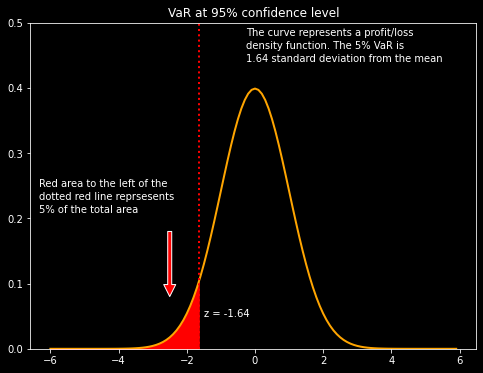

```python
# Visualize VaR at 95% confidence level
plot_var()
```

```python
# Calculate mean and standard deviation
mean = np.mean(returns['AMD'])
stdev = np.std(returns['AMD'])

# Calculate VaR at difference confidence level
VaR_90 = norm.ppf(1-0.90,mean,stdev)
VaR_95 = norm.ppf(1-0.95,mean,stdev)
VaR_99 = norm.ppf(1-0.99,mean,stdev)
```

```python
# number of stdev from the mean
norm.ppf(0.05)
```

```
-1.6448536269514729
```

```python
# Ouput results in tabular format
table = [['90%', VaR_90],['95%', VaR_95],['99%', VaR_99] ]
header = ['Confidence Level', 'Value At Risk']
print(tabulate(table,headers=header))
```

```
Confidence Level      Value At Risk
------------------  ---------------
90%                      -0.0427205
95%                      -0.0555824
99%                      -0.0797091
```

Lets now define a VaR function so that we can use it calculate it for individual stocks

**UDF : User Defined Function**

```python
# VaR function
def VaR(dataframe):
    var = pd.DataFrame()

    for i in [90, 95, 99]:
        for j in range(len(df.columns)):
            var.loc[i, j] = 100 * norm.ppf(1-i/100, dataframe.iloc[:,j].mean(), dataframe.iloc[:,j].std())

    var.columns = df.columns
    return var
```

```python
# VaR for stocks
VaR(returns)
```

|  | AMD | CSCO | INTC | INTU | NVDA |
| --- | --- | --- | --- | --- | --- |
| 90 | -4.273859 | -2.101122 | -2.739467 | -2.341609 | -3.558122 |
| 95 | -5.560556 | -2.720967 | -3.533578 | -3.050609 | -4.634948 |
| 99 | -7.974186 | -3.883693 | -5.023197 | -4.380577 | -6.654896 |

Now, let's assume that we have 1,000 shares of AMD's stock on Dec 30, 2021. What is the maximum loss next day with a confidence level of 99%?

```python
num_of_shares = 1000
price = df['AMD'].iloc[-1]
position = num_of_shares * price

amd_var = position * VaR_99

print(f'AMD Holding Value: {position}')
print(f'AMD VaR at 99% confidence level is: {amd_var}')
```

```
AMD Holding Value: 145149.99389648438
AMD VaR at 99% confidence level is: -11569.772135438907
```

VaR can also be calculated using the above formula at 99% confidence level.

```python
# VaR calculation by appling direct formulae
position * (mean + norm.ppf(1-0.99) * stdev)         # mean-2.33*stdev
```

```
-11569.772135438907
```

## Historical VaR

Asset returns do not necessarily follow a normal distribution. An alternative is to use sorted returns to evaluate a VaR. This method uses historical data where returns are sorted in ascending order to calculate maximum possible loss for a given confidence level.

```python
# Use quantile function for Historical VaR
hVaR_90 = returns['AMD'].quantile(0.10)
hVaR_95 = returns['AMD'].quantile(0.05)
hVaR_99 = returns['AMD'].quantile(0.01)
```

```python
htable = [['90%', hVaR_90],['95%', hVaR_95],['99%', hVaR_99]]
print(tabulate(htable,headers=header))
```

```
Confidence Level      Value At Risk
------------------  ---------------
90%                      -0.0334636
95%                      -0.0504089
99%                      -0.0887104
```

## MonteCarlo VaR

The Monte Carlo simulation approach has a number of similarities to historical simulation. It allows us to use actual historical distributions rather than having to assume normal returns. As returns are assumed to follow a normal distribution, we could generate *`n`* simulated returns with the same mean and standard deviation (derived from the daily returns) and then sorted in ascending order to calculate maximum possible loss for a given confidence level.

```python
# Set seed for reproducibility
np.random.seed(42)

# Number of simulations
n_sims = 5000

# Simulate returns and sort
sim_returns = np.random.normal(mean, stdev, n_sims)

# Use percentile function for MCVaR
MCVaR_90 = np.percentile(sim_returns,10)
MCVaR_95 = np.percentile(sim_returns, 5)
MCVaR_99 = np.percentile(sim_returns,1)
```

```python
mctable = [['90%', MCVaR_90],['95%', MCVaR_95],['99%', MCVaR_99]]
print(tabulate(mctable,headers=header))
```

```
Confidence Level      Value At Risk
------------------  ---------------
90%                      -0.0422902
95%                      -0.0544773
99%                      -0.0810074
```

## Scaling VaR

Now, let's calculate VaR over a 5-day period. To scale it, multiply by square root of time.
$$ VaR = position * (\mu - z * \sigma) * \sqrt{T}$$

where, $T$ is the horizon or forecast period.

```python
forecast_days = 5
f_VaR_90 = VaR_90*np.sqrt(forecast_days)
f_VaR_95 = VaR_95*np.sqrt(forecast_days)
f_VaR_99 = VaR_99*np.sqrt(forecast_days)
```

```python
ftable = [['90%', f_VaR_90],['95%', f_VaR_95],['99%', f_VaR_99] ]
fheader = ['Confidence Level', '5-Day Forecast Value At Risk']
print(tabulate(ftable,headers=fheader))
```

```
Confidence Level      5-Day Forecast Value At Risk
------------------  ------------------------------
90%                                      -0.095526
95%                                      -0.124286
99%                                      -0.178235
```

Let's now calculate AMD VaR over a 5-day period with a confidence level of 99%

```python
amd_var_5days = position * f_VaR_99

print(f'AMD Holding Value: {position}')
print(f'AMD VaR at 99% confidence level is: {amd_var_5days}')
```

```
AMD Holding Value: 145149.99389648438
AMD VaR at 99% confidence level is: -25870.7969790243
```

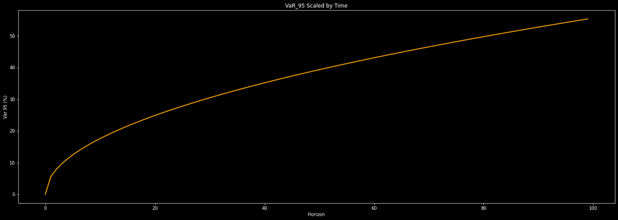

```python
# Scaled VaR over different time horizon
# plt.figure()
plt.plot(range(100),[-100*VaR_95*np.sqrt(x) for x in range(100)], color='orange')
plt.xlabel('Horizon')
plt.ylabel('Var 95 (%)')
plt.title('VaR_95 Scaled by Time');
```

## Expected Short Fall

VaR is a reasonable measure of risk if assumption of normality holds. Else, we might underestimate the risk if we observe a fat tail or overestimate the risk if tail is thinner. Expected shortfall or Conditional Value at Risk - **CVaR** - is an estimate of expected shortfall sustained in the worst 1 - x% of scenarios. It is defined as the average loss based on the returns that are lower than the VaR threshold. Assume that we have *`n`* return observations, then the expected shortfall is
$$ CVaR = \frac 1 n * \sum_{i=1}^{n} R_i[R \leq hVaR_{cl}]$$

where, $R$ is returns, $hVaR$ is historical VaR and $cl$ is the confidence level.

```python
# Calculate CVar
CVaR_90 = returns['AMD'][returns['AMD']<=hVaR_90].mean()
CVaR_95 = returns['AMD'][returns['AMD']<=hVaR_95].mean()
CVaR_99 = returns['AMD'][returns['AMD']<=hVaR_99].mean()
```

```python
ctable = [['90%', CVaR_90],['95%', CVaR_95],['99%', CVaR_99] ]
cheader = ['Confidence Level', 'Conditional Value At Risk']
print(tabulate(ctable,headers=cheader))
```

```
Confidence Level      Conditional Value At Risk
------------------  ---------------------------
90%                                  -0.0585997
95%                                  -0.0768405
99%                                  -0.125374
```

## Portfolio VaR

### Assign Weights

```python
# Weights from Minimum Variance Portfolio
weights = pd.DataFrame([0., 57.71, 13.14, 29.16, 0.0]).T
weights.columns = df.columns
weights
```

|  | AMD | CSCO | INTC | INTU | NVDA |
| --- | --- | --- | --- | --- | --- |
| 0 | 0.0 | 57.71 | 13.14 | 29.16 | 0.0 |

### Portfolio return

```python
# Portfolio returns
port_ret = np.dot(returns, weights.T)
port_mean = port_ret.mean()
port_mean
```

```
0.10387279264367698
```

### Portfolio Volatility

```python
# Portfolio volatility
port_stdev = np.sqrt(multi_dot([weights, returns.cov(), weights.T]))
port_stdev.flatten()[0]
```

```
1.5881022940351899
```

### Portfolio VaR

```python
# Calculate Portfolio VaR at difference confidence level
pVaR_90 = norm.ppf(1-0.90,port_mean,port_stdev).flatten()[0]
pVaR_95 = norm.ppf(1-0.95,port_mean,port_stdev).flatten()[0]
pVaR_99 = norm.ppf(1-0.99,port_mean,port_stdev).flatten()[0]
```

```python
# Ouput results in tabular format
ptable = [['90%', pVaR_90],['95%', pVaR_95],['99%', pVaR_99]]
header = ['Confidence Level', 'Value At Risk']
print(tabulate(ptable,headers=header))
```

```
Confidence Level      Value At Risk
------------------  ---------------
90%                        -1.93136
95%                        -2.50832
99%                        -3.59061
```

Let's now compare the portfolio VaR numbers with that of the individual stocks

```python
# Iterate over symbols
portpos=0.
for stock in df.columns:
    pos = df[stock].iloc[-1] * 1000*weights[stock][0]
    pvar = VaR(returns)[stock].iloc[1]

    print(f'{stock} Holding Value: {pos:0.8}')
    print(f'{stock} VaR at 95% confidence level: {pvar:0.8}%')
    print()

    portpos += pos

print(f'Portfolio Holding Value: {portpos:0.8}')
print(f'Portoflio VaR at 95% confidence level: {pVaR_95:0.3}%')
```

```
AMD Holding Value: 0.0
AMD VaR at 95% confidence level: -5.560556%

CSCO Holding Value: 3650002.1
CSCO VaR at 95% confidence level: -2.7209672%

INTC Holding Value: 674723.79
INTC VaR at 95% confidence level: -3.5335776%

INTU Holding Value: 1.8738623e+07
INTU VaR at 95% confidence level: -3.0506094%

NVDA Holding Value: 0.0
NVDA VaR at 95% confidence level: -4.6349484%

Portfolio Holding Value: 2.3063349e+07
Portoflio VaR at 95% confidence level: -2.51%
```

# References

- [Scipy](https://urldefense.com/v3/__https://docs.scipy.org/doc/scipy/reference/__;!!KGvANbslH1YjwA!pp8ABRV5pvlNNVDnmbQpGv8z5Wc4lDFJ3s74EFrfiGXolaNAXRMhuhP5AupxkJs7xpOLJTeFiw$)
- [Tabulate](https://urldefense.com/v3/__https://github.com/astanin/python-tabulate__;!!KGvANbslH1YjwA!pp8ABRV5pvlNNVDnmbQpGv8z5Wc4lDFJ3s74EFrfiGXolaNAXRMhuhP5AupxkJs7xpPIoOvwlA$)
- Paul Wilmott (2007), Paul Wilmott introduces Quantitative Finance

[Kannan Singaravelu](https://urldefense.com/v3/__http://twitter.com/kannansi__;!!KGvANbslH1YjwA!pp8ABRV5pvlNNVDnmbQpGv8z5Wc4lDFJ3s74EFrfiGXolaNAXRMhuhP5AupxkJs7xpOvShO3hg$) | [GitHub](https://urldefense.com/v3/__https://github.com/kannansingaravelu__;!!KGvANbslH1YjwA!pp8ABRV5pvlNNVDnmbQpGv8z5Wc4lDFJ3s74EFrfiGXolaNAXRMhuhP5AupxkJs7xpPquleyhw$)

March, 2022